# Cross-border response clusters across the completed revised grid

All 96 observations pooled; scenario profiles and sensitivity checks

Published

October 2, 2026

## What was analysed and what it yields

This analysis pools **all 96 completed revised-grid observations**: twelve circular-economy scenarios (1–4 and 6–13), each measured on eight combinations of external closure and regional aggregation. Each observation contains the responses of **both regions together**, at period 90 relative to that arm’s baseline. No submitted-model observations or construction scenarios 5 and 14 enter this analysis, following the maintainer’s stated scope. No scenario is omitted from the completed grid.

**Observed:** Ward clustering of the full pooled response vectors selects **seven groups**, with mean silhouette **0.483130**, among candidate cuts k = 2…8. The group sizes are **3, 20, 65, 3, 1, 1 and 3**. This is a descriptive partition of scenario/configuration responses, not evidence of seven independent transmission mechanisms. Two groups contain only one observation, and 65 of 96 observations belong to a broad mixed group.

A complementary analysis gives each of the twelve scenarios **one profile containing its responses across all eight arms**. Its best Ward cut is **two groups**: `{10,13}` and `{1,2,3,4,6,7,8,9,11,12}`, with mean silhouette **0.386980**. This grouping survives removal of any single arm, but average and complete linkage instead isolate scenario 1. The analysis therefore does not establish a unique, method-independent regime count or confirm the manuscript’s four-way taxonomy.

The computation is `R/scenarios/cluster_transmission_grid.R`; the results and their full source-cache hashes are under `output/calibration/transmission_clusters_20261002/`. The code and results were prepared after review commit `92bf8f9`. These are exploratory, deterministic comparisons, not samples of independent empirical observations.

## Joint responses, features and scaling

The analysis retains the six outcome blocks used in the earlier cross-border clustering script `R/scenarios/cluster_block_analysis.R`: real activity; fiscal outcomes; external trade/accounts; labour and functional distribution; finance and wealth; ecological outcomes. There are **37 candidate measures per region**, giving 74 potential joint coordinates for each pooled observation. Both signed regional responses are retained. Clustering only on Z1 minus Z2 would lose information about whether a given difference arose from two expansions, two contractions or opposite movements; that coordinate system is reported as a secondary sensitivity only.

Most coordinates are percent changes, `100 × (scenario / own-arm baseline − 1)`. Current account (`cab`), trade balance (`tb`) and government deficit (`gdef`) use `100 × (scenario − baseline) / own regional baseline VA` because dividing by a near-zero or sign-changing flow can manufacture large responses. Income shares and the debt/VA ratio use 100 times their level difference, in percentage points. The engine’s functional-inequality index (`ineq`) uses 100 times its index difference; it is not a household inequality statistic. All bases, levels and denominators remain in `responses.csv`.

Within each cohort and coordinate space, features with missing/nonfinite entries or standard deviation ≤ 10⁻⁸ are removed, with reasons recorded in `feature_audit.csv`. Each retained column is centred and divided by its sample standard deviation. Each block’s columns are then divided by the square root of the number retained in that block, so a block with more correlated variables does not receive more total marginal variance merely because it has more columns. This does not remove within-block correlations or accounting identities. Equal weighting of individual columns is also checked.

The distance is Euclidean and the primary linkage is Ward D2. The chosen k maximises the mean silhouette over 2…8; no hand-labelled regimes or fitted VA thresholds select the features or cut. A silhouette measures how close an observation is to its own group relative to its nearest competing group; a singleton receives zero. The R implementations are documented in [hclust](https://stat.ethz.ch/R-manual/R-devel/library/stats/html/hclust.html) and [silhouette](https://stat.ethz.ch/R-manual/R-devel/library/cluster/html/silhouette.html).

All 96 shock hashes and eight baseline hashes were checked against the completed grid records before extraction. Baseline and shock file paths are recorded for every observation in `inputs.csv`, together with the corresponding SHA-256 digests. No accepted simulation was repeated, no old clustering RDS was overwritten, and no manuscript or scenario definition changed.

## The pooled seven-group partition

Group numbers are arbitrary identifiers. Their composition is:

| Group | Observations | Measured composition |
| --- | --- | --- |
| 1 | 3 | North/South household-food scenario 1 under gold, fiat and quasi-float |
| 2 | 20 | Energy scenarios 2 and 13 across all eight arms, plus metal-production scenario 10 on the four EU/RoW arms |
| 3 | 65 | Remaining small/mixed responses: all arms of scenarios 3, 6, 7, 8, 11 and 12, plus some food and plastics observations |
| 4 | 3 | North/South metal-production scenario 10 under gold, fiat and quasi-float |
| 5 | 1 | North/South OPENFIXG household-food scenario 1 |
| 6 | 1 | North/South OPENFIXG metal-production scenario 10 |
| 7 | 3 | EU/RoW OPENFIXG scenarios 1, 4 and 9 (household food; government plastics; production plastics) |

The membership matrix shows every observation. In particular, scenarios 1, 4, 9 and 10 cross cluster boundaries when the configuration changes. A single scenario label does not capture the full set of its closure/regional responses.

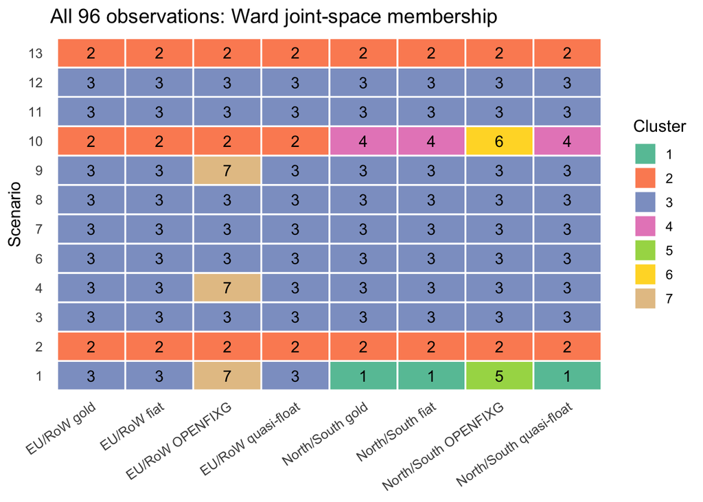

To show how these groups relate to cross-border activity, the next figure plots their actual VA responses. The clustering was fitted to all six blocks, so a group is not defined by its position in this two-variable projection.

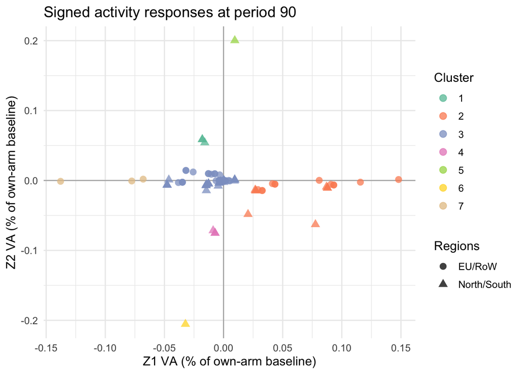

**Interpretation:** the pooled partition mixes scenario type, regional aggregation, closure adjustment and magnitude. Group 2 combines the two energy interventions with EU/RoW metal production, although those scenarios carry distinct FIC/CD names in the fitted rule. North/South metal production separates from its EU/RoW counterpart. OPENFIXG produces individual or small groups for food and metal responses whose magnitudes differ from their gold/fiat/quasi-float counterparts. These are measured differences in the response vectors; clustering alone does not identify their causal mechanism.

## Choice of cut and comparison with the fitted rule

Source: silhouettes.csv; pooled joint space, all six blocks. Each candidate cut includes all 96 observations.

| k | silhouette | smallest_cluster | singletons |
| --- | --- | --- | --- |
| 2 | 0.399940 | 24 | 0 |
| 3 | 0.394623 | 4 | 0 |
| 4 | 0.444085 | 4 | 0 |
| 5 | 0.449588 | 1 | 1 |
| 6 | 0.473683 | 1 | 1 |
| 7 | 0.483130 | 1 | 2 |
| 8 | 0.462570 | 1 | 2 |

Source: rule_comparison.csv; adjusted Rand agreement with the existing τ = 0.003% VA rule, evaluated after clustering.

| k | ari_to_fitted_rule |
| --- | --- |
| 2 | 0.404999 |
| 3 | 0.429846 |
| 4 | 0.526299 |
| 5 | 0.527623 |
| 6 | 0.466223 |
| 7 | 0.464915 |
| 8 | 0.686726 |

The fitted threshold rule labels SC either for a small absolute region-2 VA response or for two contractions; it gives PL for Z1 contraction with Z2 expansion, CD/FIC for the opposite sign combination, and UN for two expansions. SC therefore already combines two different propositions. The comparison uses that complete rule, including the both-negative branch, at the same period and own-baseline response basis. `rule_labels.csv` records its inputs and assignments.

At the silhouette-selected k = 7, adjusted Rand agreement with this rule is **0.464915**. At k = 8 it rises to **0.686726**, but mean silhouette falls to **0.462570**. Choosing k = 8 to improve agreement would change the question from discovering response groups to reproducing a fitted taxonomy. The existing labels are neither validation data nor a criterion for this unsupervised cut. Adjusted Rand values compare pairs grouped together by two partitions, correcting for chance agreement; they are not significance tests here.

## How much is repeated structure across arms?

The 96 rows represent twelve interventions on eight related model configurations. They are not 96 independent interventions. Near-identical gold and fiat trajectories can create very tight repeated groups. The twelve-profile analysis instead concatenates each scenario’s eight signed regional outcome vectors, retaining all 96 observations as inputs while clustering twelve scenario objects. Standardisation and block weighting are recomputed for that representation; 578 coordinates survive the variance floor.

Its selected Ward groups are the metal- and energy-production pair `{10,13}` versus the other ten scenarios. This is **not a closure-averaged response**: different arms occupy different columns, and opposing signs are not averaged away. The two-group silhouette (0.386980) barely exceeds the three-group silhouette (0.384022); the third group is a singleton. The small difference does not make two a precisely identified population count.

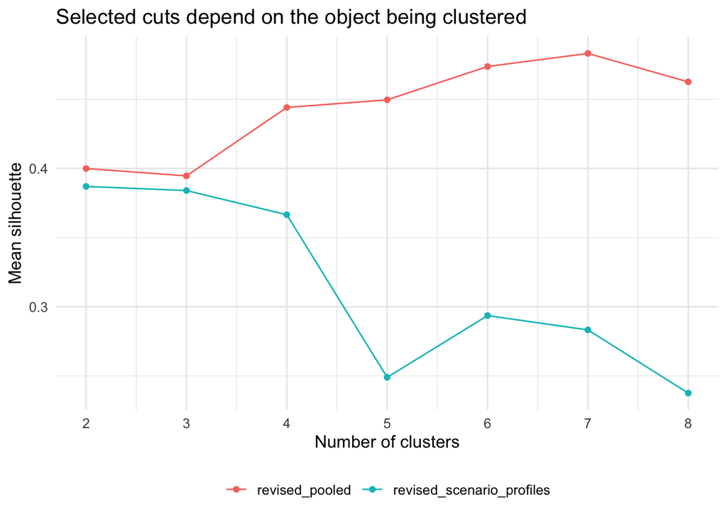

Source: memberships.csv; one concatenated profile per scenario, using all eight arms.

| sample | cluster |
| --- | --- |
| Sc01 | 1 |
| Sc02 | 1 |
| Sc03 | 1 |
| Sc04 | 1 |
| Sc06 | 1 |
| Sc07 | 1 |
| Sc08 | 1 |
| Sc09 | 1 |
| Sc10 | 2 |
| Sc11 | 1 |
| Sc12 | 1 |
| Sc13 | 2 |

## Blocks, per-arm fits and sensitivity

Source: summary.csv; all-block and individual-block joint-space fits.

| cohort | block | n | features | k | silhouette | smallest_cluster |
| --- | --- | --- | --- | --- | --- | --- |
| revised_pooled | All blocks | 96 | 74 | 7 | 0.483130 | 1 |
| revised_pooled | Real activity | 96 | 12 | 7 | 0.606288 | 1 |
| revised_pooled | Fiscal | 96 | 10 | 8 | 0.590714 | 1 |
| revised_pooled | External | 96 | 8 | 8 | 0.588291 | 1 |
| revised_pooled | Labour and distribution | 96 | 18 | 2 | 0.678611 | 4 |
| revised_pooled | Finance and wealth | 96 | 10 | 2 | 0.629623 | 4 |
| revised_pooled | Ecological | 96 | 16 | 2 | 0.684716 | 4 |
| revised_scenario_profiles | All blocks | 12 | 578 | 2 | 0.386980 | 2 |
| revised_scenario_profiles | Real activity | 12 | 96 | 3 | 0.452878 | 1 |
| revised_scenario_profiles | Fiscal | 12 | 66 | 2 | 0.515482 | 1 |
| revised_scenario_profiles | External | 12 | 64 | 2 | 0.547166 | 1 |
| revised_scenario_profiles | Labour and distribution | 12 | 144 | 2 | 0.462397 | 1 |
| revised_scenario_profiles | Finance and wealth | 12 | 80 | 2 | 0.388435 | 2 |
| revised_scenario_profiles | Ecological | 12 | 128 | 4 | 0.379863 | 1 |

Source: summary.csv; separately standardised twelve-scenario fits within each arm.

| cohort | features | k | silhouette | smallest_cluster |
| --- | --- | --- | --- | --- |
| arm_revised | 72 | 2 | 0.396461 | 3 |
| arm_revised_ns | 72 | 3 | 0.538492 | 1 |
| arm_revised_openfixg | 73 | 2 | 0.292501 | 3 |
| arm_revised_ns_openfixg | 73 | 2 | 0.516770 | 1 |
| arm_revised_quasifloat | 72 | 2 | 0.397515 | 3 |
| arm_revised_ns_quasifloat | 72 | 3 | 0.534639 | 1 |
| arm_revised_openfix_fiat | 72 | 3 | 0.394876 | 3 |
| arm_revised_ns_openfix_fiat | 72 | 3 | 0.539774 | 1 |

The block fits do not agree on a count. Pooled labour/distribution, finance/wealth and ecological blocks each select two groups, whereas pooled real activity selects seven and fiscal/external blocks select eight. A k = 8 maximum lies at the upper boundary of the declared search range and is not a demonstrated optimum over all possible cuts. The within-arm full fits select two or three groups, sometimes with a singleton. The all-block pooled seven-way result is therefore not a count supported uniformly by the outcome blocks or by each arm separately.

Sensitivity comparisons hold the selected baseline k fixed while removing each block, removing each arm, changing linkage, or giving each feature equal weight. Arm-removal comparisons use only the observations common to both fits; the profile comparisons retain all twelve scenarios and remove that arm’s columns. These are descriptive stress tests, not bootstrap confidence intervals.

Source: sensitivity.csv; ARI against each cohort’s original joint-space cut at fixed k (7 pooled, 2 scenario profiles).

| cohort | test | n | ari |
| --- | --- | --- | --- |
| revised_pooled | omit block Real activity | 96 | 0.767084 |
| revised_pooled | omit block Fiscal | 96 | 0.386798 |
| revised_pooled | omit block External | 96 | 0.502625 |
| revised_pooled | omit block Labour and distribution | 96 | 1.000000 |
| revised_pooled | omit block Finance and wealth | 96 | 1.000000 |
| revised_pooled | omit block Ecological | 96 | 0.767084 |
| revised_pooled | linkage average | 96 | 0.471168 |
| revised_pooled | linkage complete | 96 | 0.502625 |
| revised_pooled | equal weight per feature | 96 | 1.000000 |
| revised_pooled | omit arm revised | 84 | 1.000000 |
| revised_pooled | omit arm revised_ns | 84 | 0.742201 |
| revised_pooled | omit arm revised_openfixg | 84 | 0.744964 |
| revised_pooled | omit arm revised_ns_openfixg | 84 | 0.726957 |
| revised_pooled | omit arm revised_quasifloat | 84 | 1.000000 |
| revised_pooled | omit arm revised_ns_quasifloat | 84 | 0.742201 |
| revised_pooled | omit arm revised_openfix_fiat | 84 | 1.000000 |
| revised_pooled | omit arm revised_ns_openfix_fiat | 84 | 0.742201 |
| revised_scenario_profiles | omit block Real activity | 12 | 1.000000 |
| revised_scenario_profiles | omit block Fiscal | 12 | 1.000000 |
| revised_scenario_profiles | omit block External | 12 | 1.000000 |
| revised_scenario_profiles | omit block Labour and distribution | 12 | 1.000000 |
| revised_scenario_profiles | omit block Finance and wealth | 12 | 0.640950 |
| revised_scenario_profiles | omit block Ecological | 12 | 1.000000 |
| revised_scenario_profiles | linkage average | 12 | -0.109589 |
| revised_scenario_profiles | linkage complete | 12 | -0.109589 |
| revised_scenario_profiles | equal weight per feature | 12 | 1.000000 |
| revised_scenario_profiles | omit arm revised | 12 | 1.000000 |
| revised_scenario_profiles | omit arm revised_ns | 12 | 1.000000 |
| revised_scenario_profiles | omit arm revised_openfixg | 12 | 1.000000 |
| revised_scenario_profiles | omit arm revised_ns_openfixg | 12 | 1.000000 |
| revised_scenario_profiles | omit arm revised_quasifloat | 12 | 1.000000 |
| revised_scenario_profiles | omit arm revised_ns_quasifloat | 12 | 1.000000 |
| revised_scenario_profiles | omit arm revised_openfix_fiat | 12 | 1.000000 |
| revised_scenario_profiles | omit arm revised_ns_openfix_fiat | 12 | 1.000000 |

For the pooled fit, removing a block yields ARI **0.386798–1.000000**; removing an arm yields **0.726957–1.000000**. Average/complete linkage yield **0.471168 / 0.502625**. Equal feature weighting gives ARI 1.000000. For the scenario profiles, each arm removal gives ARI 1.000000; removing finance/wealth gives ARI **0.640950**, with the other block removals unchanged. Average and complete linkage both isolate scenario 1 and yield ARI **−0.109589** relative to Ward’s `{10,13}` split. Their memberships are preserved in `alternative_memberships.csv`.

## What can be claimed

The completed revised grid contains distinguishable cross-border response patterns, with regional aggregation and OPENFIXG responses contributing to the pooled structure. The existing four-name rule and the unsupervised groups answer different questions. The observed seven groups should be reported with their membership and method, not renamed as seven economic regimes. Nor should the two-profile cut be treated as a universal replacement taxonomy: it is sensitive to linkage and nearly tied with a singleton-containing third group.

All results depend on period 90, the selected variables, their denominators, block weighting, and the stated distance/linkage. Z1/Z2 mean EU/RoW or North/South according to the arm, so this pooling compares ordinal regional roles, not identical geographical populations. The two aggregations and closures also have calibrated baselines; clustering is not causal identification. Cumulative ecological stocks and correlated accounting measures can contribute to distance even though they are not independent mechanisms. Functional-distribution coordinates describe income classes, not individual-household inequality.

Scenario 6 remains included exactly as simulated; its near-inert revised intervention does not establish ineffectiveness of replacement-capital substitution. Fiat finite-horizon responses do not demonstrate a new stationary equilibrium. The four maintainer choices (scenario 6, `par_xr`, the short North/South fiat reserve and the premium with Ξ) remain open. No manuscript claim is revised by this analysis.

## Reproduce and inspect

Run from the repository root:

```bash
Rscript R/scenarios/cluster_transmission_grid.R 20261002
quarto render qmd/reports/2026-10-02-pooled-transmission-clusters.qmd --to html --output-dir "$PWD/output/html/reports"
```

The report uses CSVs in `output/calibration/transmission_clusters_20261002/`: `inputs.csv` and `responses.csv` preserve provenance and denominators; `feature_audit.csv` records omissions; `summary.csv`, `silhouettes.csv`, `memberships.csv`, `pooled_composition.csv`, `centroids.csv`, `scenario_consistency.csv`, `sensitivity.csv`, `alternative_memberships.csv`, `rule_labels.csv` and `rule_comparison.csv` expose the results. `provenance.json` records code/status/rule hashes, source commit and settings. `fits.RDS` is a regenerable local fit cache, not an input required by this report.